# Practical 1

**Aim of this practical:** In this first practical we are going to look at some simple models

1. A Gaussian model with simulated data
2. A GLM model with random effects

we are going to learn:

- How to fit a simple model with `inlabru`
- How to explore the results
- How to change the prior distributions
- How to get predictions for missing data points

## Linear Model

Start by loading usefull libraries:

```r
library(dplyr)
library(INLA)
library(ggplot2)
library(patchwork)
library(inlabru)
# load some libraries to generate nice map plots
library(scico)
```

As our first example we consider a simple linear regression model with Gaussian observations $y_i\sim\mathcal{N}(\mu_i, \sigma^2)$, $i = 1,\dots,N$ where $\sigma^2$ is the observation error, and the mean parameter $\mu_i$ is linked to the linear predictor through an identity function:
$$\eta_i = \mu_i = \beta_0 + \beta_1 x_i$$
where $x_i$ is a covariate and $\beta_0, \beta_1$ are parameters to be estimated.

To finalize the Bayesian model we need to assign a $\text{Gamma}(a,b)$ prior to the precision parameter $\tau = 1/\sigma^2$ and two independent Gaussian priors with mean $0$ and precision $\tau_{\beta}$ to the regression parameters $\beta_0$ and $\beta_1$.

**Question**

What is the dimension of the hyperparameter vector and latent Gaussian field?

The hyperparameter vector has dimension 1, $\pmb{\theta} = (\tau)$ while the latent Gaussian field $\pmb{u} = (\beta_0, \beta_1)$ has dimension 2, $0$ mean, and sparse precision matrix:

$$\pmb{Q} = \tau_{\beta}\begin{bmatrix}
1 & 0\\
0 & 1
\end{bmatrix}$$

**Note**

We can write the linear predictor vector $\pmb{\eta} = (\eta_i,\dots,\eta_N)$ as

$$\pmb{\eta} = \pmb{A}\pmb{u} = \pmb{A}_1\pmb{u}_1 + \pmb{A}_2\pmb{u}_2 = \begin{bmatrix}
1 \\
1\\
\vdots\\
1
\end{bmatrix} \beta_0 + \begin{bmatrix}
x_1 \\
x_2\\
\vdots\\
x_N
\end{bmatrix} \beta_1$$

Our linear predictor consists then of two components.

### **Simulate example data**

In this practical we will use simulated Gaussian data to get familiar with the `inlabru` workflow. Moreover, we will see how to change the prior distributions both for the fixed effects $\beta_0$ and $\beta_1$ and for the hyperparameter $\tau = 1/\sigma^2$. First, we simulate data from the model

with

$$\eta_i = \beta_0 + \beta_1 x_i$$

```r
beta = c(1,1)
sd_error = 1

n = 100
x = rnorm(n)
y = beta[1] + beta[2] * x + rnorm(n, sd = sd_error)

df = data.frame(y = y, x = x)
```

### **Fitting a linear regression model with `inlabru`**

**Defining model components**

The model has two parameters to be estimated $\beta_1$ and $\beta_2$. We need to define the two corresponding model components:

```r
cmp =  ~ Intercept(1) + beta_1(x, model = "linear")
```

The `cmp` object is here used to define model components. We can give them any useful names we like

**Note**

Note that `Intercept()` is one of `inlabru` special names and it is used to define a global intercept. You should explicitly exclude automatic intercept when not using the special `Intercept` name, e.g.

```r
cmp =  ~ -1 + myIntercept(1) + beta_1(x, model = "linear")
```

**Observation model construction**

The next step is to construct the observation model by defining the model likelihood. The most important inputs here are the `formula`, the `family` and the `data`.

The `formula` defines how the components should be combined in order to define the model predictor.

```r
formula = y ~ Intercept + beta_1
```

**Note**

In this case we can also use the shortcut `formula = y ~ .`. This will tell `inlarbu` that the model is linear and that it is not necessary to linearize the model and assess convergence.

The likelihood is defined using the `bru_obs()` function as follows:

```r
lik =  bru_obs(formula = y ~.,
            family = "gaussian",
            data = df)
```

**Fit the model**

We fit the model using the `bru()` functions which takes as input the components and the observation model:

```r
fit.lm = bru(cmp, lik)
```

The `summary()` function will give access to some basic information about model fit and estimates

```r
summary(fit.lm)
```

```
inlabru version: 2.12.0
INLA version: 24.06.27
Components:
Intercept: main = linear(1), group = exchangeable(1L), replicate = iid(1L), NULL
beta_1: main = linear(x), group = exchangeable(1L), replicate = iid(1L), NULL
Likelihoods:
  Family: 'gaussian'
    Tag: ''
    Data class: 'data.frame'
    Response class: 'numeric'
    Predictor: y ~ .
    Used components: effects[Intercept, beta_1], latent[]
Time used:
    Pre = 0.629, Running = 0.302, Post = 0.103, Total = 1.03
Fixed effects:
           mean    sd 0.025quant 0.5quant 0.975quant  mode kld
Intercept 1.067 0.114      0.843    1.067      1.291 1.067   0
beta_1    0.923 0.120      0.688    0.923      1.158 0.923   0

Model hyperparameters:
                                         mean    sd 0.025quant 0.5quant
Precision for the Gaussian observations 0.784 0.111      0.582    0.778
                                        0.975quant  mode
Precision for the Gaussian observations       1.02 0.768

Deviance Information Criterion (DIC) ...............: 314.15
Deviance Information Criterion (DIC, saturated) ....: 105.38
Effective number of parameters .....................: 2.99

Watanabe-Akaike information criterion (WAIC) ...: 314.41
Effective number of parameters .................: 3.12

Marginal log-Likelihood:  -176.48
 is computed
Posterior summaries for the linear predictor and the fitted values are computed
(Posterior marginals needs also 'control.compute=list(return.marginals.predictor=TRUE)')
```

We can see that both the intercept and slope and the error precision are correctly estimated. We can then plot the marginal posterior for $\beta_0$ as follows:

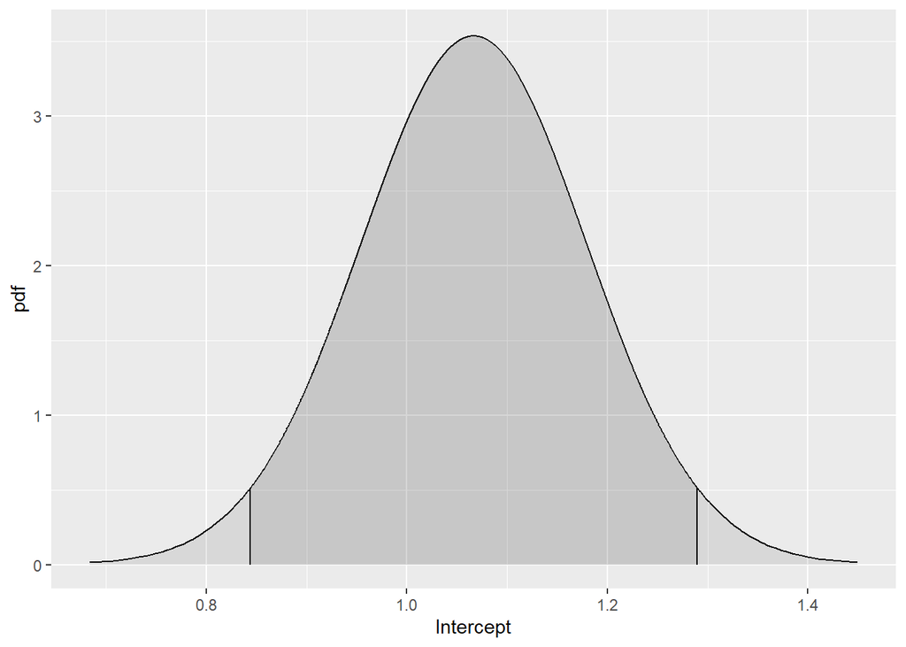

```r
plot(fit.lm, "Intercept")
```

**Task**

Plot the posterior marginals for $\beta_1$ and for the precision of the observation error $\pi(\tau|y)$

See the `summary()` output to check the names for the different model components.

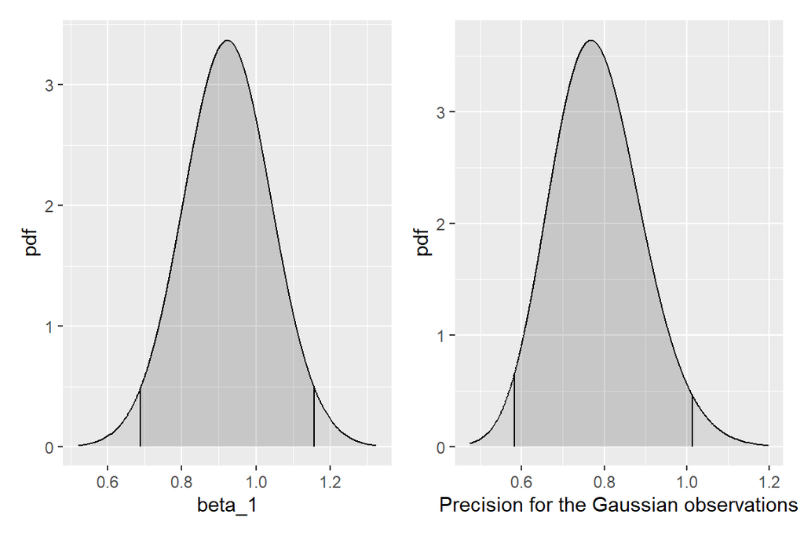

```r
plot(fit.lm, "beta_1") +
plot(fit.lm, "Precision for the Gaussian observations")
```

**Task**

Plot the fitted values with 95% Credible intervals.

`bru` objects information about the linear predictor can be accessed through `fit.lm$summary.fitted.values`.

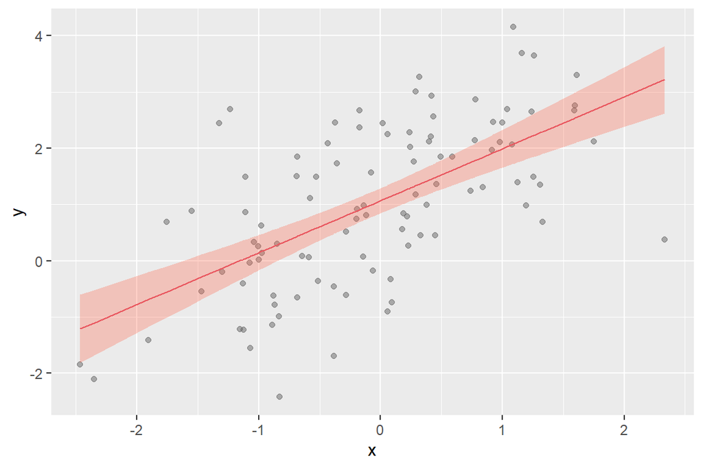

```r
df %>% mutate(post_mean = fit.lm$summary.fitted.values[1:100,"mean"],
              q25 = fit.lm$summary.fitted.values[1:100,"0.025quant"],
              q975 = fit.lm$summary.fitted.values[1:100,"0.975quant"])%>%
  ggplot()+geom_point(aes(x=x,y=y),alpha=0.5,color="grey40")+
  geom_line(aes(x=x,y=post_mean),col=2)+
  geom_ribbon(aes(x = x, ymax = q975, ymin = q25),fill="tomato", alpha = 0.3)
```

### Generate model predictions

Now we can take the fitted `bru` object and use the `predict` function to produce predictions given a new set of values for the model covariates or the original values used for the model fit

```r
new_data = data.frame(x = c(df$x, runif(10)),
                      y = c(df$y, rep(NA,10)))
pred = predict(fit.lm, new_data, ~ Intercept + beta_1)
```

**Plot**

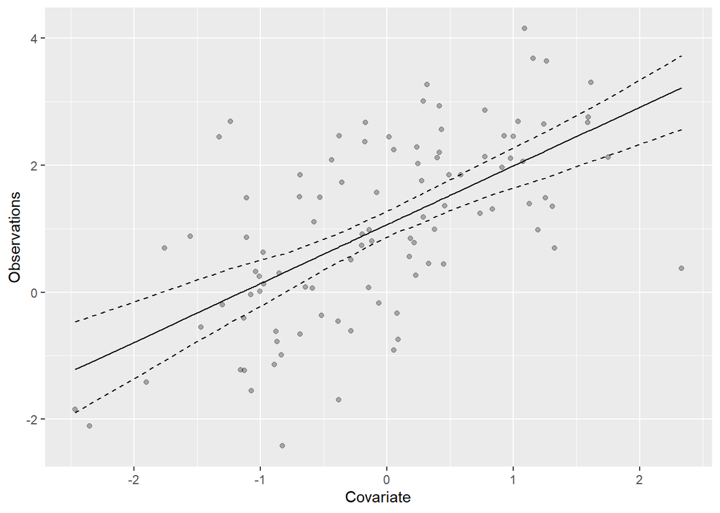

Data and 95% credible intervals

**R Code**

```r
pred %>% ggplot() +
  geom_point(aes(x,y), alpha = 0.3) +
  geom_line(aes(x,mean)) +
  geom_line(aes(x, q0.025), linetype = "dashed")+
  geom_line(aes(x, q0.975), linetype = "dashed")+
  xlab("Covariate") + ylab("Observations")
```

# Linear Mixed Model

Consider the same linear model as in Section 0.1 except with the addition that the data that comes in groups. For each group $j$, we have an associated variable $v_j \sim \mathcal{N}(0, \tau^{-1}_v)$.

The predictor for this model is
$$\mathbb{E}\left[ y_{ij} \right] = \beta_0 + \beta_1 x_i + v_j$$
The model design matrix for the random effect has one row for each observation. The row of the design matrix associated with the $ij$-th observation consists of zeroes except for the element associated with $v_j$, which has a one.

##### *Simulate example data*

```r
library(inlabru)
library(INLA)
library(ggplot2)
library(dplyr)
```

```r
beta = c(1.5,1)
sd_error = 1
tau_group = 1

n = 100
n.groups = 5
x = rnorm(n)
v = rnorm(n.groups, sd = tau_group^{-1/2})
y = beta[1] + beta[2] * x + rnorm(n, sd = sd_error) +
  rep(v, each = 20)

df = data.frame(y = y, x = x, j = rep(1:5, each = 20))
```

Note that `inlabru` expects an integer indexing variable to label the groups.

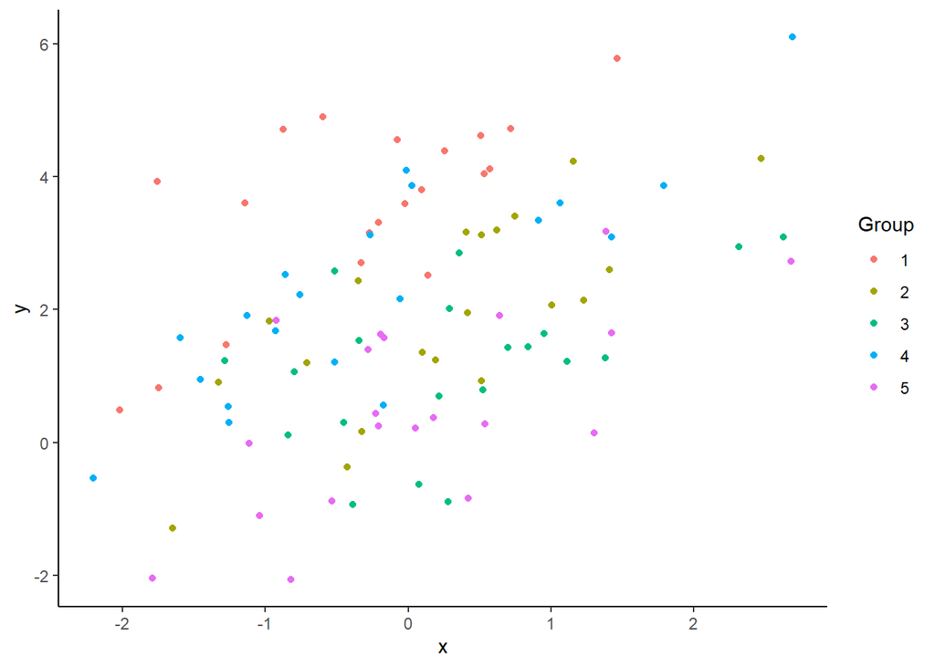

Data for the linear mixed model example with 5 groups

```r
df$jfac = as.factor(df$j)
ggplot(df) +
  geom_point(aes(x = x, colour = jfac, y = y)) +
  theme_classic() +
  scale_colour_discrete("Group")
```

#### *Define model components and likelihood*

```r
# Define model components
cmp =  ~ Intercept(1) + beta_1(x, model = "linear") +
  v(j, model = "iid")
```

The group variable is indexed by column `j` in the dataset. We have chosen to name this component `v()` to connect with the mathematical notation that we used above.

```r
# Construct likelihood
lik =  like(formula = y ~.,
            family = "gaussian",
            data = df)
```

##### *Fit the model*

The model can be fitted exactly as in the previous examples by using the `bru` function with the components and likelihood objects.

```r
fit = bru(cmp, lik)
summary(fit)
```

```
inlabru version: 2.12.0
INLA version: 24.06.27
Components:
Intercept: main = linear(1), group = exchangeable(1L), replicate = iid(1L), NULL
beta_1: main = linear(x), group = exchangeable(1L), replicate = iid(1L), NULL
v: main = iid(j), group = exchangeable(1L), replicate = iid(1L), NULL
Likelihoods:
  Family: 'gaussian'
    Tag: ''
    Data class: 'data.frame'
    Response class: 'numeric'
    Predictor: y ~ .
    Used components: effects[Intercept, beta_1, v], latent[]
Time used:
    Pre = 0.483, Running = 0.571, Post = 0.332, Total = 1.39
Fixed effects:
           mean    sd 0.025quant 0.5quant 0.975quant  mode kld
Intercept 1.878 0.564      0.748    1.879      3.008 1.878   0
beta_1    0.933 0.100      0.736    0.933      1.128 0.933   0

Random effects:
  Name    Model
    v IID model

Model hyperparameters:
                                         mean    sd 0.025quant 0.5quant
Precision for the Gaussian observations 0.973 0.141      0.721    0.964
Precision for v                         0.930 0.587      0.221    0.793
                                        0.975quant  mode
Precision for the Gaussian observations       1.27 0.949
Precision for v                               2.44 0.549

Deviance Information Criterion (DIC) ...............: 296.60
Deviance Information Criterion (DIC, saturated) ....: 109.09
Effective number of parameters .....................: 6.79

Watanabe-Akaike information criterion (WAIC) ...: 296.47
Effective number of parameters .................: 6.28

Marginal log-Likelihood:  -182.78
 is computed
Posterior summaries for the linear predictor and the fitted values are computed
(Posterior marginals needs also 'control.compute=list(return.marginals.predictor=TRUE)')
```